# Data Analysis HW4

Artin Tajdini 95109983

March 9, 2018

```r
school = read_rds("D:/Downloads/Data tims/bcg.rds") # school background
student = read_rds("D:/Downloads/Data tims/bsg.rds") # student background
teacher = read_rds("D:/Downloads/Data tims/btm.rds") # Teacher background
stresult = read_rds("D:/Downloads/Data tims/bsa.rds") # strudent result
stt = read_rds("D:/Downloads/Data tims/bst.rds") # student-teacher linkage
country = read_rds("D:/Downloads/Data tims/bsr.rds") # within-country
```

# سؤال ۱

ابتدا داده رضایت معلم دانش آموز با نمره دانش آموز را داخل یک جدول می ریزیم. سپس با فرض صفر یکی بودن نمره ها در همه حالات تست آنوا میزنیم و فرض صفر رد می شود پس رضایت معلم بر نمره دانش آموز تاثیر دارد.(نوع تاثیر خواسته نشده است اما از نمودار میتوان حدس زد که معلمانی که راضی اند اما نه خیلی بهترین نمرات را دارند.)

```r
full_join(
teacher %>%
  select(idteach, idcntry, satic = btbg10b),
    stt %>%
      select(idstud, idcntry, idteach, bsmmat01:bsmmat05),
  by = c("idcntry", "idteach")
) %>% mutate(
  score = bsmmat01 + bsmmat02 + bsmmat03 + bsmmat04 + bsmmat05
    ) %>%
  distinct %>%
  filter(!is.na(satic)) -> d1

hcboxplot(x = as.numeric(d1$score), var = as.character(d1$satic), name="Length",color="tomato")
```

[interactive chart not shown]

```r
d1 %>%
  aov(satic ~ score, data = .) %>%
  summary.aov()
```

```
                Df Sum Sq Mean Sq F value Pr(>F)
score            1    282  282.30   485.4 <2e-16 ***
Residuals   273845 159247    0.58
---
Signif. codes:  0 '***' 0.001 '**' 0.01 '*' 0.05 '.' 0.1 ' ' 1
```

# سؤال ۲

نمرات دانش آموزان را برحسب تحصیلات والدین گروه میکنیم و با فرض صفر یکی بودن آنوا میزنیم و رد میشود. پس تاثیر دارد و حال بین بیشترین میزان و کمترین میزان تحصیلات والدین تیتست یکطرفه میزنیم و با رد شدن آن میابیم که تحصیلات والدین تاثیر مثبت دارد.

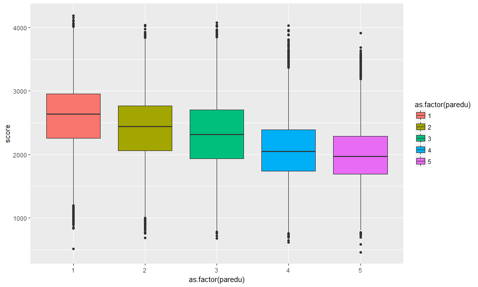

```r
student %>%
  select(idstud, idcntry, bsmmat01:bsmmat05, paredu = bsdgedup) %>%
  mutate(score = bsmmat01 + bsmmat02 + bsmmat03 + bsmmat04 + bsmmat05) %>%
  filter(!is.na(paredu), paredu != 6) -> d2

d2 %>%
  ggplot(aes(x = as.factor(paredu), y = score, fill = as.factor(paredu))) +
  geom_boxplot()
```

```r
d2 %>%
  aov(score ~ paredu, data = .) %>%
  summary()
```

```
                Df    Sum Sq   Mean Sq F value Pr(>F)
paredu           1 7.783e+09 7.783e+09   30736 <2e-16 ***
Residuals   212843 5.390e+10 2.532e+05
---
Signif. codes:  0 '***' 0.001 '**' 0.01 '*' 0.05 '.' 0.1 ' ' 1
```

```r
d2 %>%
  spread(paredu, score) %>%
  t.test(.$"1", .$"5", data = ., alt = "greater")
```

```
    Welch Two Sample t-test

data:  .$"1" and .$"5"
t = 141.52, df = 21441, p-value < 2.2e-16
alternative hypothesis: true difference in means is greater than 0
95 percent confidence interval:
 581.1044      Inf
sample estimates:
mean of x mean of y
 2596.163  2008.225
```

# سؤال ۳

برای پیداکردن مقدار امکانات رفاهی مقدار ۱۱ سؤال مربوط به امکانات را جمع میزنیم سپس با فرض صفر کورلیشن کمتر مساوی صفرکورلیشن تست میزنیم و رد میشود پس ارتباط مستقیم دارند

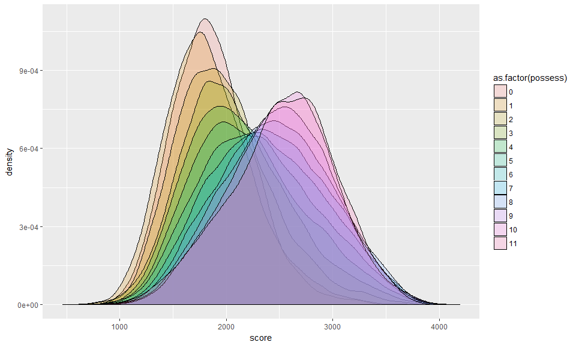

```r
student %>%
  select(idstud, idcntry, bsmmat01:bsmmat05, bsbg06a:bsbg06k) %>%
  mutate( score = rowSums(.[3:7], na.rm = T),
          possess = 22 - rowSums(.[8:18], na.rm = T)) %>% na.omit() -> d3

d3 %>%
  ggplot(., aes(x = score, fill = as.factor(possess))) + geom_density(alpha = 0.2)
```

```r
d3 %>%
  cor.test(~ score + possess, alternative = "greater", data = .)
```

```
    Pearson's product-moment correlation

data:  score and possess
t = 118.98, df = 190660, p-value < 2.2e-16
alternative hypothesis: true correlation is greater than 0
95 percent confidence interval:
 0.2593991 1.0000000
sample estimates:
      cor
0.2629092
```

# سؤال ۶

با فرض صفر بهتر بودن پسر ها در هندسه تی تست میزنیم و چون پی ولیو خیلی کم است رد میشود.

```r
stresult %>%
  select(idstud, idcntry, bsmgeo01:bsmgeo05, itsex) %>%
  mutate(geom = bsmgeo01 + bsmgeo02 + bsmgeo03 + bsmgeo04 + bsmgeo05) -> d6

t.test(geom~itsex, data = d6, alt = "greater")
```

```
    Welch Two Sample t-test

data:  geom by itsex
t = 9.2376, df = 279150, p-value < 2.2e-16
alternative hypothesis: true difference in means is greater than 0
95 percent confidence interval:
 15.6619     Inf
sample estimates:
mean in group 1 mean in group 2
       2371.857        2352.802
```

```r
d6 %>%
  group_by(itsex) %>%
  summarise(avrgeom = mean(geom)) %>%
  hchart(., hcaes(x = itsex, y = avrgeom), type = "column") %>%
  hc_xAxis(categories = c("", "female", "male"))
```

[interactive chart not shown]

# سؤال ۷

یادگیری ۴ حالت دارد و صبحانه خوردن نیز ۴ حالت پس هردو گسسته هستند و تست Chi-square میزنیم با فرض صفر مستقل بودن این دو متغیر از هم که چون پی ولیو بسیار کم است رد می شود

```r
student %>%
  select(idstud, idcntry, learn = bsbg15g, eat = bsbg12) %>%
  na.omit() %>%
  group_by(learn, eat) %>%
  summarise(count = n()) %>%
  spread(eat, count) -> d7

d7 %>% .[,-1] %>% as.matrix() %>% chisq.test()
```

```
    Pearson's Chi-squared test

data:  .
X-squared = 2907.6, df = 9, p-value < 2.2e-16
```

```r
d7 %>% select(learn, a = "1", b = "2", c = "3", d = "4") %>%
  mutate(a = a / sum(.$a),
         b = b / sum(.$b),
         c = c / sum(.$c),
         d = d / sum(.$d)) %>%
  .[,-1] %>% as.matrix() %>% hchart() %>%
  hc_colorAxis(stops = color_stops())
```

[interactive chart not shown]

# سؤال ۹

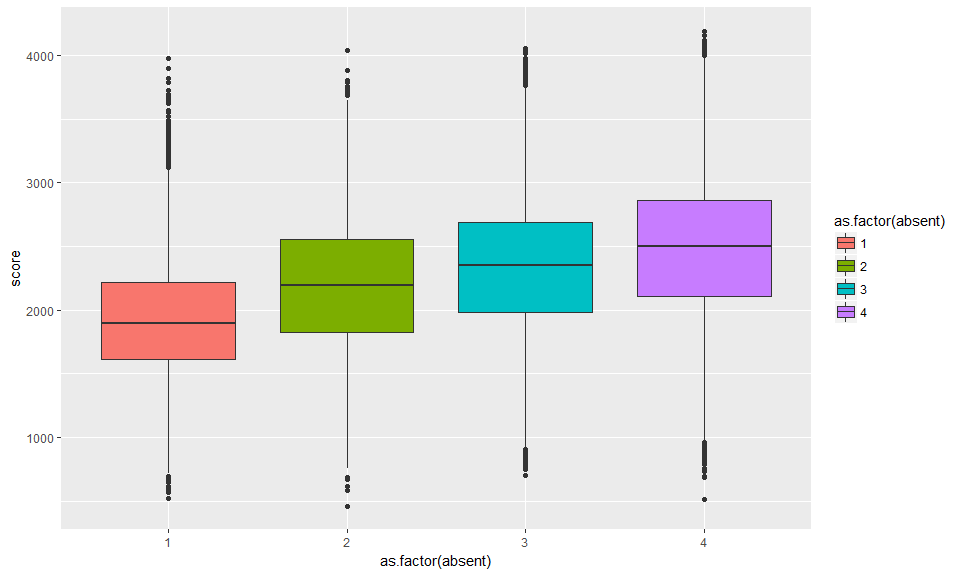

```r
student %>%
  select(idstud, idcntry, bsmmat01:bsmmat05, absent = bsbg11) %>%
  mutate(score = bsmmat01 + bsmmat02 + bsmmat03 + bsmmat04 + bsmmat05) -> d9

  d9 %>% filter(!is.na(absent)) %>%
    ggplot(aes(x = as.factor(absent), y = score, fill = as.factor(absent))) +
    geom_boxplot()
```

```r
  d9 %>%
  aov(score ~ absent, data = .) %>%
  summary.aov()
```

```
                Df    Sum Sq   Mean Sq F value Pr(>F)
absent           1 6.621e+09 6.621e+09   25650 <2e-16 ***
Residuals   264983 6.840e+10 2.581e+05
---
Signif. codes:  0 '***' 0.001 '**' 0.01 '*' 0.05 '.' 0.1 ' ' 1
15145 observations deleted due to missingness
```

```r
  d9 %>% filter(!is.na(absent)) %>%
    cor.test(~ score + absent, alternative = "greater", data = .)
```

```
    Pearson's product-moment correlation

data:  score and absent
t = 160.16, df = 264980, p-value < 2.2e-16
alternative hypothesis: true correlation is greater than 0
95 percent confidence interval:
 0.294161 1.000000
sample estimates:
      cor
0.2970771
```

# سؤال ۱۰

```r
student %>% filter(idcntry == 364) %>%
  select(idstud, bsmapp01:bsmapp05, bsmrea01:bsmrea05) %>%
  mutate( apply = rowSums(.[2:6], na.rm = T),
          reason = rowSums(.[7:11], na.rm = T) ) %>%
  t.test(.$apply, .$reason, data = .)
```

```
    Welch Two Sample t-test

data:  .$apply and .$reason
t = -1.1953, df = 12236, p-value = 0.232
alternative hypothesis: true difference in means is not equal to 0
95 percent confidence interval:
 -26.770394   6.489197
sample estimates:
mean of x mean of y
 2207.516  2217.657
```

```r
student %>% filter(idcntry == 364) %>%
  select(idstud, bsmapp01:bsmapp05, bsmrea01:bsmrea05) %>%
  mutate( apply = rowSums(.[2:6], na.rm = T),
          reason = rowSums(.[7:11], na.rm = T) ) -> d10

hchart(density(d10$apply), area = TRUE) %>% hc_add_series(density(d10$reason), area = TRUE)
```

[interactive chart not shown]

# تاثیر اذیت شدن دانش آموز توسط بقیه روی نمراتش

گروه میکنیم و آنوا میزنیم و میابیم که گروه ها یکی نیستند چون فرض صفر آنوا رد شده است سپس بین گروه اول و آخر تی تست میزنیم و میابیم ارتباط طبق انتظار منفی است

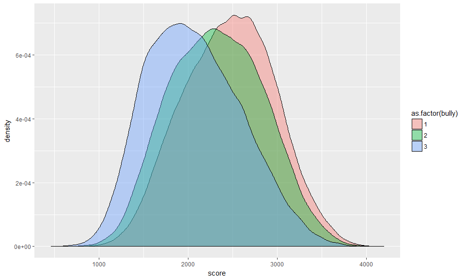

```r
student %>%
  select(idstud, idcntry, bsmmat01:bsmmat05, bully = bsdgsb) %>%
  mutate(score = bsmmat01 + bsmmat02 + bsmmat03 + bsmmat04 + bsmmat05) %>%
  filter(!is.na(bully)) -> d11

d11 %>%
  ggplot(., aes(x = score, fill = as.factor(bully))) + geom_density(alpha = 0.4)
```

```r
d11 %>%
  aov(score ~ bully, data = .) %>%
  summary()
```

```
                Df    Sum Sq   Mean Sq F value Pr(>F)
bully            1 3.271e+09 3.271e+09   12286 <2e-16 ***
Residuals   269984 7.188e+10 2.662e+05
---
Signif. codes:  0 '***' 0.001 '**' 0.01 '*' 0.05 '.' 0.1 ' ' 1
```

```r
d11 %>%
  spread(bully, score) %>%
  t.test(.$"1", .$"3", data = ., alt = "greater")
```

```
    Welch Two Sample t-test

data:  .$"1" and .$"3"
t = 104.83, df = 29464, p-value < 2.2e-16
alternative hypothesis: true difference in means is greater than 0
95 percent confidence interval:
 381.3152      Inf
sample estimates:
mean of x mean of y
 2459.846  2072.452
```

# تاثیر اعتماد به نفس در زیست روی نمرات ریاضی!!

آنوا میزنیم و میبینیم که یکی نیستند گروه ها بر حسب اعتماد به نفس سپس کورلیشن تست میزنیم و میبینیم تاثیر مثبت دارد

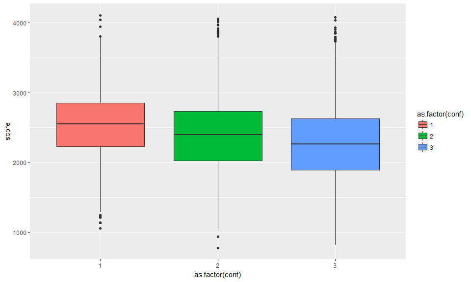

```r
student %>%
  select(idstud, idcntry, bsmmat01:bsmmat05, conf = bsdgscb) %>%
  mutate(score = bsmmat01 + bsmmat02 + bsmmat03 + bsmmat04 + bsmmat05) %>%
  filter(!is.na(conf)) -> d12

d12 %>%
  ggplot(aes(x = as.factor(conf), y = score, fill = as.factor(conf))) +
  geom_boxplot()
```

```r
d12 %>%
  aov(score ~ conf, data = .) %>%
  summary()
```

```
               Df    Sum Sq   Mean Sq F value Pr(>F)
conf            1 4.314e+08 431418843    1894 <2e-16 ***
Residuals   47454 1.081e+10    227834
---
Signif. codes:  0 '***' 0.001 '**' 0.01 '*' 0.05 '.' 0.1 ' ' 1
```

```r
d12 %>%
  cor.test(~ score + conf, alternative = "less", data = .)
```

```
    Pearson's product-moment correlation

data:  score and conf
t = -43.515, df = 47454, p-value < 2.2e-16
alternative hypothesis: true correlation is less than 0
95 percent confidence interval:
 -1.0000000 -0.1886162
sample estimates:
      cor
-0.195888
```

# تاثیر میزان تکلیف بر نمره دانش آموزان

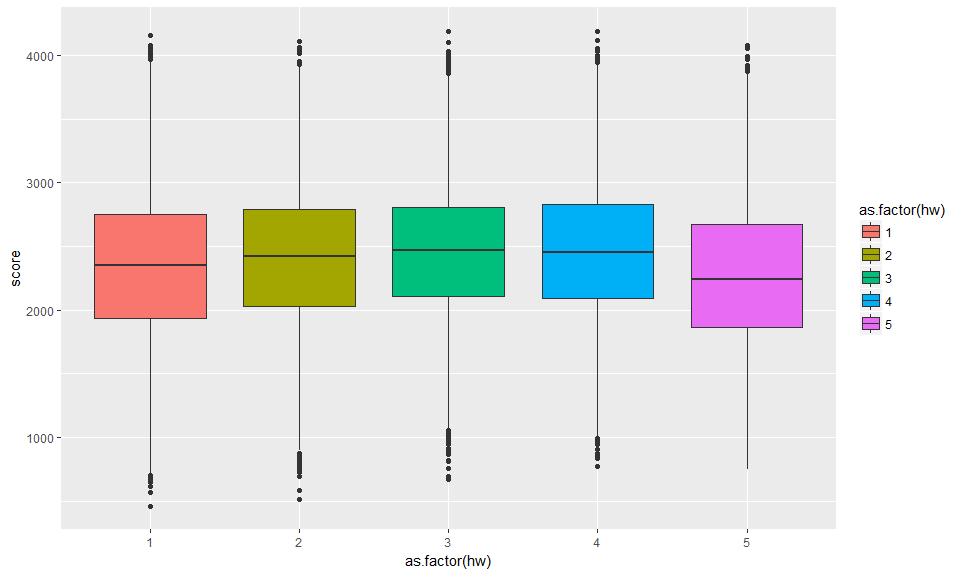

```r
student %>%
  select(idstud, idcntry, bsmmat01:bsmmat05, hw = bsbm38aa) %>%
  mutate(score = bsmmat01 + bsmmat02 + bsmmat03 + bsmmat04 + bsmmat05) %>%
  filter(!is.na(hw)) -> d13

d13 %>%
  ggplot(aes(x = as.factor(hw), y = score, fill = as.factor(hw))) +
  geom_boxplot()
```

```r
d13 %>%
  aov(score ~ hw, data = .) %>%
  summary()
```

```
                Df    Sum Sq   Mean Sq F value Pr(>F)
hw               1 1.736e+08 173611082   626.4 <2e-16 ***
Residuals   270546 7.498e+10    277145
---
Signif. codes:  0 '***' 0.001 '**' 0.01 '*' 0.05 '.' 0.1 ' ' 1
```

```r
d13 %>%
  spread(hw, score) %>%
  t.test(.$"1", .$"2", data = ., alt = "greater")
```

```
    Welch Two Sample t-test

data:  .$"1" and .$"2"
t = -27.687, df = 177370, p-value = 1
alternative hypothesis: true difference in means is greater than 0
95 percent confidence interval:
 -72.89319       Inf
sample estimates:
mean of x mean of y
 2345.558  2414.364
```

```r
d13 %>%
  spread(hw, score) %>%
  t.test(.$"2", .$"3", data = ., alt = "greater")
```

```
    Welch Two Sample t-test

data:  .$"2" and .$"3"
t = -15.459, df = 119280, p-value = 1
alternative hypothesis: true difference in means is greater than 0
95 percent confidence interval:
 -48.08611       Inf
sample estimates:
mean of x mean of y
 2414.364  2457.826
```

```r
d13 %>%
  spread(hw, score) %>%
  t.test(.$"3", .$"4", data = ., alt = "greater")
```

```
    Welch Two Sample t-test

data:  .$"3" and .$"4"
t = -0.18729, df = 39448, p-value = 0.5743
alternative hypothesis: true difference in means is greater than 0
95 percent confidence interval:
 -7.479404       Inf
sample estimates:
mean of x mean of y
 2457.826  2458.590
```

```r
d13 %>%
  spread(hw, score) %>%
  t.test(.$"4", .$"5", data = ., alt = "greater")
```

```
    Welch Two Sample t-test

data:  .$"4" and .$"5"
t = 27.61, df = 19766, p-value < 2.2e-16
alternative hypothesis: true difference in means is greater than 0
95 percent confidence interval:
 165.7807      Inf
sample estimates:
mean of x mean of y
 2458.590  2282.307
```